# Exam 1: Intro to R

Liam Maher

2024-10-01

### Libraries

Include any libraries that you use here. Do not include the *install.packages()* code. The markdown file will not run.

```r
library(tidyverse)
library(openintro)
```

### Exercise 0

Download the baseball.csv dataset from the Canvas course. The dataset contains information on 59 baseball players. The variables are as follows: - height: Height of the player in inches - weight: Weight of the player in pounds - bat: L if they bat left handed, R if they bat right handed - throw: L if they throw left handed, R if they throw right handed - field: 0 if they are a pitcher, 1 if they are a fielder - avg: either their pitching averages or fielding average depending on field

```r
baseball <- read.csv("~/Desktop/baseball.csv")
```

### Exercise 1

Define a new variable called BMI, which means body mass index. The formula for BMI is

$$BMI = \frac{\text{weight} \times
703}{\text{height}^2}$$

where weight is in pounds and height is in inches. Calculate the mean and standard deviation of all players BMI. Create a histogram for BMI for all players. Comment on the shape and center of the histogram. Then create a subset for the fielders and pitchers BMI and create a stacked histogram. Compare the two groups.

```r
baseball$BMI <- (baseball$weight * 703) / (baseball$height^2)

mean_BMI <- mean(baseball$BMI, na.rm = TRUE)
sd_BMI <- sd(baseball$BMI, na.rm = TRUE)

mean_BMI
```

```
## [1] 24.80068
```

```r
sd_BMI
```

```
## [1] 1.73092
```

```r
median(baseball$BMI, na.rm = TRUE)
```

```
## [1] 24.99556
```

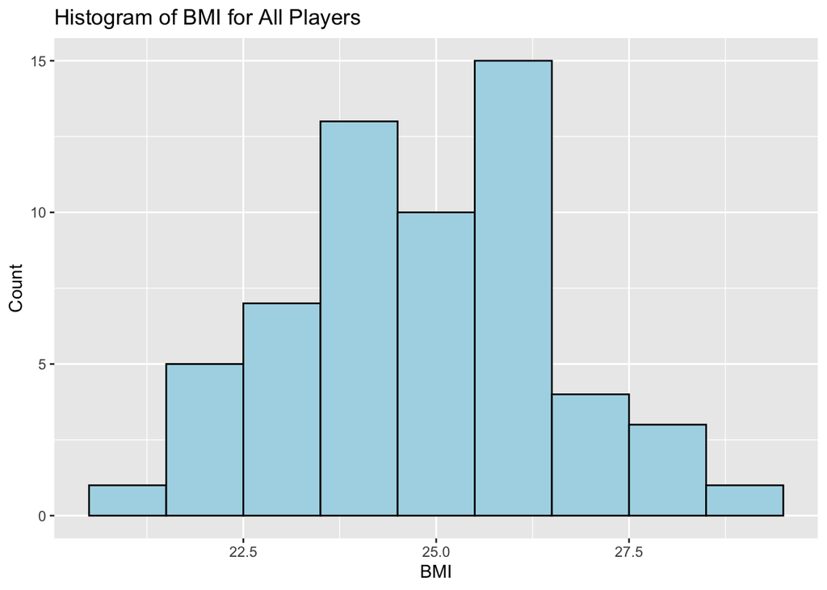

```r
ggplot(baseball, aes(x = BMI)) +
  geom_histogram(binwidth = 1, fill = "lightblue", color = "black") +
  ggtitle("Histogram of BMI for All Players") +
  xlab("BMI") +
  ylab("Count")
```

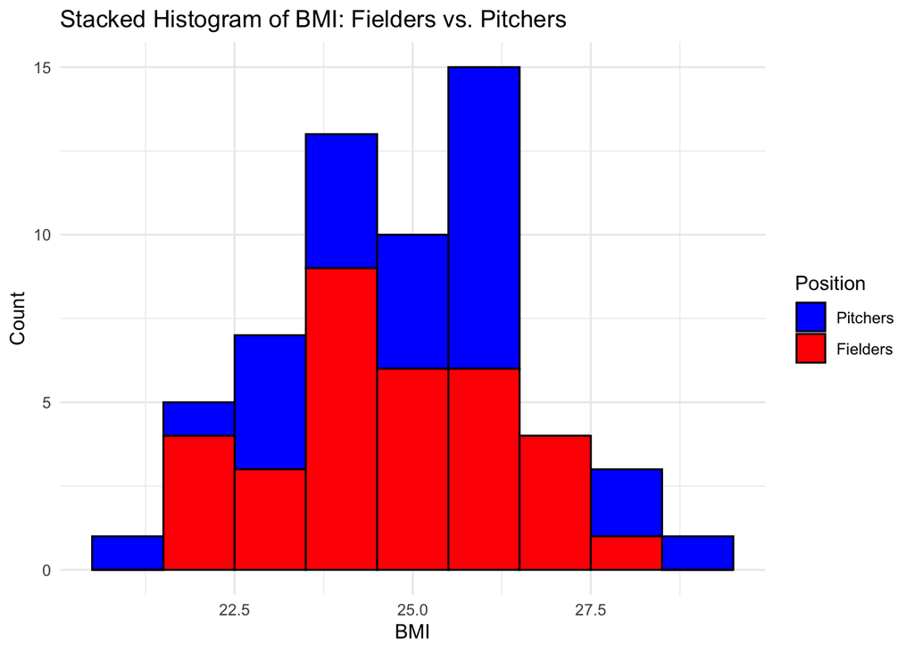

```r
fielders <- subset(baseball, field == 1)
pitchers <- subset(baseball, field == 0)

# Create a stacked histogram for fielders and pitchers using ggplot2
ggplot(baseball, aes(x = BMI, fill = as.factor(field))) +
  geom_histogram(binwidth = 1, position = "stack", color = "black") +
  scale_fill_manual(values = c("0" = "blue", "1" = "red"),
                    labels = c("Pitchers", "Fielders")) +
  labs(title = "Stacked Histogram of BMI: Fielders vs. Pitchers",
       x = "BMI", y = "Count", fill = "Position") +
  theme_minimal()
```

### Exercise 2

- Add the variable overweight to the dataset. A player is considered overweight if their BMI is greater than 25. Create a table of the number of overweight and non-overweight players. Which group has more players in it? What is the mean and of the overweight players? What about for the non-overweight?
- Create a stacked barplot of the number of overweight and non-overweight players based on position. Comment on your findings. Create a boxplot of the BMI of the players based on overweight. Comment on the distribution of the heights based on the dominant batting hand. Are there outliers?
- Create a contingency table for the dominant batting hand of the players and their overweightness. Which dominant hand group has more overweight players?

```r
baseball$overweight <- ifelse(baseball$BMI > 25, "Overweight", "Non-overweight")

overweight_table <- table(baseball$overweight)
print(overweight_table)
```

```
##
## Non-overweight     Overweight
##             30             29
```

```r
mean_overweight <- mean(baseball$BMI[baseball$overweight == "Overweight"], na.rm = TRUE)
mean_non_overweight <- mean(baseball$BMI[baseball$overweight == "Non-overweight"], na.rm = TRUE)

cat("Mean BMI for overweight players:", mean_overweight, "\n")
```

```
## Mean BMI for overweight players: 26.18435
```

```r
cat("Mean BMI for non-overweight players:", mean_non_overweight, "\n")
```

```
## Mean BMI for non-overweight players: 23.46313
```

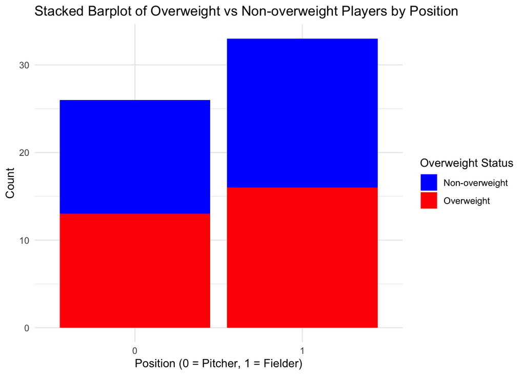

```r
ggplot(baseball, aes(x = as.factor(field), fill = overweight)) +
  geom_bar(position = "stack") +
  scale_fill_manual(values = c("Overweight" = "red", "Non-overweight" = "blue"),
                    name = "Overweight Status") +
  labs(x = "Position (0 = Pitcher, 1 = Fielder)", y = "Count",
       title = "Stacked Barplot of Overweight vs Non-overweight Players by Position") +
  theme_minimal()
```

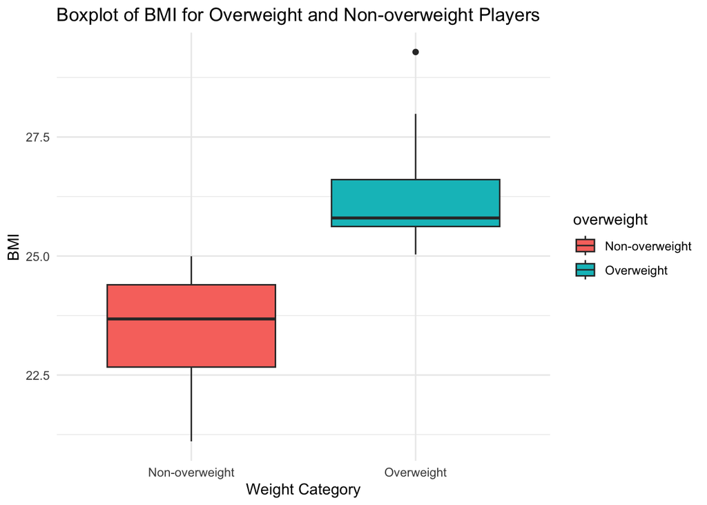

```r
#boxplot of Overwigeight and non overweight players BMI
ggplot(baseball, aes(x = overweight, y = BMI, fill = overweight)) +
  geom_boxplot() +
  labs(title = "Boxplot of BMI for Overweight and Non-overweight Players",
       x = "Weight Category", y = "BMI") +
  theme_minimal()
```

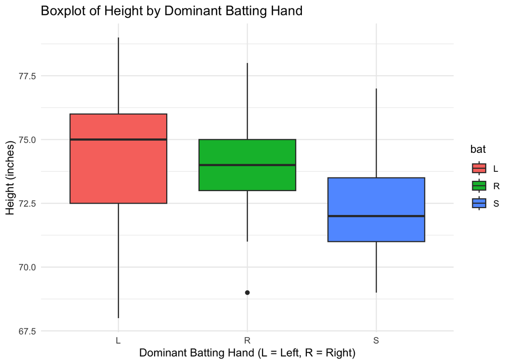

```r
#Boxplot of height based on dom hand
ggplot(baseball, aes(x = bat, y = height, fill = bat)) +
  geom_boxplot() +
  labs(title = "Boxplot of Height by Dominant Batting Hand",
       x = "Dominant Batting Hand (L = Left, R = Right)", y = "Height (inches)") +
  theme_minimal()
```

```r
#Contingency table
contingency_table <- table(baseball$bat, baseball$overweight)
print(contingency_table)
```

```
##
##     Non-overweight Overweight
##   L              5         10
##   R             18         15
##   S              7          4
```

More players are not overweight. (Assuming “and” was BMI and autocorrected) Mean BMI for overweight players is 26.18 and mean BMI for non-overweight players is 23.46. For the stacked barplot, it shows that more Fielders than pitchers, as well as that there are more fielders that are overweight than pitchers that are overweight, as well as more fielders that are not overwight than pitchers that are not overweight.

I made a boxplot to look at the distributions based on batting hand, the largest spread is definelty that of left, it also has the highest IQR, and the heighest median (75 inches). Right handed is the next highest median (about 74 inches), but contains an outlier at around 69 inches, it also has the smallest IQR. Switch has the smallest median at about 72 inches, and does not contain any outliers.

Right handed has the most overweight players.

### Exercise 3

- Create a scatterplot of Average vs. BMI. Comment on the relationship between the two variables.
- Create a new scatterplot with the points colored by field. Comment on your new findings.

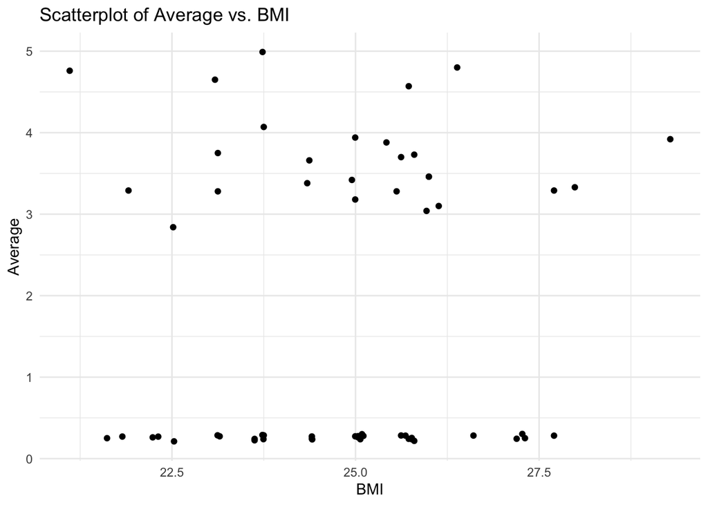

```r
#scatterplot
ggplot(baseball, aes(x = baseball$BMI, y = average)) +
  geom_point() +
  labs(title = "Scatterplot of Average vs. BMI",
       x = "BMI",
       y = "Average") +
  theme_minimal()
```

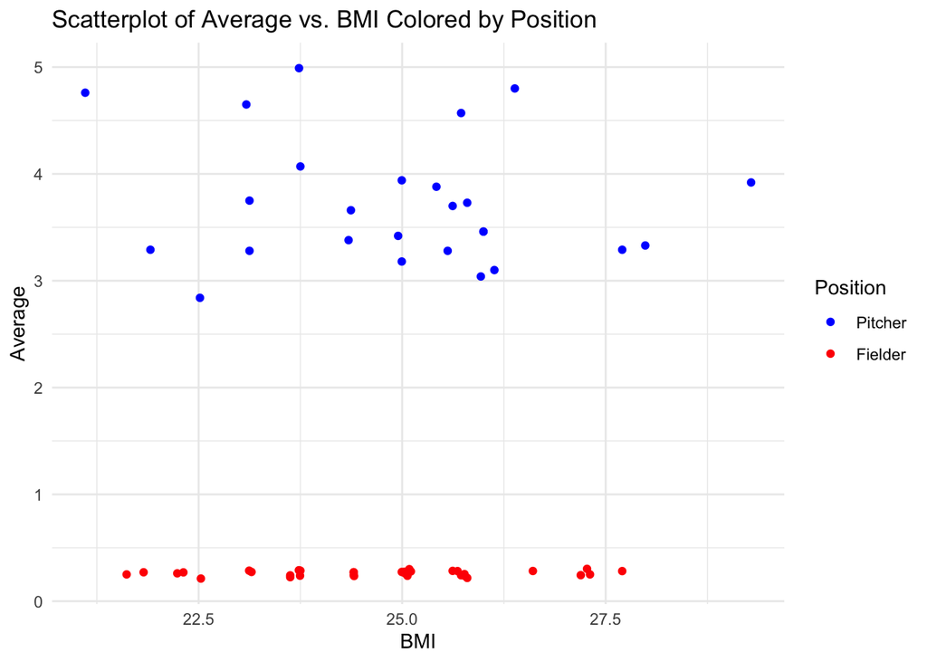

```r
#scatterplot by field
ggplot(baseball, aes(x = baseball$BMI, y = average, color = as.factor(field))) +
  geom_point() +
  scale_color_manual(values = c("0" = "blue", "1" = "red"),
                     labels = c("Pitcher", "Fielder")) +
  labs(title = "Scatterplot of Average vs. BMI Colored by Position",
       x = "BMI",
       y = "Average",
       color = "Position") +
  theme_minimal()
```

There is no correlation between BMI and average. We can see two groupings of averages though, one around 3-5, and one all below .5.

There is still no correlation between BMI and average. However, now we can see that the two groups we saw before are that of pitchers (higher average group (~3-5)) and fielders (lower average group (0-0.5))

### Exercise 4

- Run a linear regression model to predict the average of the players based on their BMI. Interpret the coefficients of the model.
- What is the predicted average for a player with a BMI of 25? If the actual value was .262 would the model over or underpredict the value? If the actual value was 3.460 would the model over or underpredict the value? Why do you think there could be such disparity between the two residuals?
- How much of the percent of variation in average is explained by its linear relationship with BMI?
- What is the correlation coefficient?

```r
model <- lm(average ~ BMI, data = baseball)
summary(model)
```

```
##
## Call:
## lm(formula = average ~ BMI, data = baseball)
##
## Residuals:
##    Min     1Q Median     3Q    Max
## -1.708 -1.526 -1.349  1.624  3.277
##
## Coefficients:
##             Estimate Std. Error t value Pr(>|t|)
## (Intercept)  0.08248    3.37124   0.024    0.981
## BMI          0.06871    0.13561   0.507    0.614
##
## Residual standard error: 1.788 on 57 degrees of freedom
## Multiple R-squared:  0.004484,   Adjusted R-squared:  -0.01298
## F-statistic: 0.2568 on 1 and 57 DF,  p-value: 0.6143
```

```r
# Predict the average for a player with a BMI of 25
predicted_avg <- predict(model, data.frame(BMI = 25))
cat("Predicted average for a player with a BMI of 25:", predicted_avg, "\n")
```

```
## Predicted average for a player with a BMI of 25: 1.800323
```

```r
actual_value_1 <- 0.262
actual_value_2 <- 3.460

cat("For actual value 0.262, the model",
    ifelse(predicted_avg > actual_value_1, "overpredicts", "underpredicts"), "\n")
```

```
## For actual value 0.262, the model overpredicts
```

```r
cat("For actual value 3.460, the model",
    ifelse(predicted_avg > actual_value_2, "overpredicts", "underpredicts"), "\n")
```

```
## For actual value 3.460, the model underpredicts
```

```r
#calc r squared
r_squared <- summary(model)$r.squared
cat("R-squared (percent of variation explained):", r_squared * 100, "%\n")
```

```
## R-squared (percent of variation explained): 0.4484188 %
```

```r
#calc corr coeff
correlation_coefficient <- cor(baseball$BMI, baseball$average, use = "complete.obs")
cat("Correlation coefficient between BMI and average:", correlation_coefficient, "\n")
```

```
## Correlation coefficient between BMI and average: 0.06696408
```

The regression equation would be y(hat) = 0.08248 + 0.06871x. That means that when a players BMI is 0 (unrealistic but what our model uses to predict) they would have an average of 0.08248. It also means for every 1 increase in BMI, the players average increases by .06871.

The predicted average is 1.800323. If the actual value was 0.262, it overpredicts: 0.262 - 1.800323 = -1.538323. If the actual value was 3.460 the model underpredicts: 3.460-1.800323 = 1.659677. Those are the residuals. The discrepency could be due to the fact that the model uses BMI to predict average of all players, and the average values of pitchers and fielders is very different as we saw before.

The R squared value is .004484 and shows us that .448% of the variation in average is explained by BMI.

The correlation coeff is sqrt() of r^2 is approximately 0.06696. This indicates a very very weak positive linear relationship. A correlation coefficient of 0 indicates no linear relationship exists between the variables, and this is very close to 0.

### Exercise 5

- Define `Simpson’s Paradox’
- Create two subsets of data based on field. Run a regression on each subset. Compare the coefficients of the two models with the model you ran in Exercise 4.
- Do you find the two models are significantly different from the model you made in Exercise 4 when you account for field position?

```r
pitchers <- subset(baseball, field == 0)
fielders <- subset(baseball, field == 1)


# Linear regression for all players (Exercise 4)
model_all <- lm(average ~ BMI, data = baseball)
summary(model_all)
```

```
##
## Call:
## lm(formula = average ~ BMI, data = baseball)
##
## Residuals:
##    Min     1Q Median     3Q    Max
## -1.708 -1.526 -1.349  1.624  3.277
##
## Coefficients:
##             Estimate Std. Error t value Pr(>|t|)
## (Intercept)  0.08248    3.37124   0.024    0.981
## BMI          0.06871    0.13561   0.507    0.614
##
## Residual standard error: 1.788 on 57 degrees of freedom
## Multiple R-squared:  0.004484,   Adjusted R-squared:  -0.01298
## F-statistic: 0.2568 on 1 and 57 DF,  p-value: 0.6143
```

```r
# Regression for pitchers
model_pitchers <- lm(average ~ BMI, data = pitchers)
summary(model_pitchers)
```

```
##
## Call:
## lm(formula = average ~ BMI, data = pitchers)
##
## Residuals:
##     Min      1Q  Median      3Q     Max
## -1.0142 -0.4024 -0.1512  0.2661  1.2011
##
## Coefficients:
##             Estimate Std. Error t value Pr(>|t|)
## (Intercept)  5.06086    1.59548   3.172  0.00411 **
## BMI         -0.05359    0.06369  -0.841  0.40838
## ---
## Signif. codes:  0 '***' 0.001 '**' 0.01 '*' 0.05 '.' 0.1 ' ' 1
##
## Residual standard error: 0.5986 on 24 degrees of freedom
## Multiple R-squared:  0.02866,    Adjusted R-squared:  -0.01181
## F-statistic: 0.7081 on 1 and 24 DF,  p-value: 0.4084
```

```r
# Regression for fielders
model_fielders <- lm(average ~ BMI, data = fielders)
summary(model_fielders)
```

```
##
## Call:
## lm(formula = average ~ BMI, data = fielders)
##
## Residuals:
##       Min        1Q    Median        3Q       Max
## -0.046231 -0.020951  0.009675  0.016212  0.037252
##
## Coefficients:
##             Estimate Std. Error t value Pr(>|t|)
## (Intercept) 0.210466   0.063812   3.298  0.00245 **
## BMI         0.002084   0.002583   0.807  0.42588
## ---
## Signif. codes:  0 '***' 0.001 '**' 0.01 '*' 0.05 '.' 0.1 ' ' 1
##
## Residual standard error: 0.02365 on 31 degrees of freedom
## Multiple R-squared:  0.02057,    Adjusted R-squared:  -0.01102
## F-statistic: 0.6511 on 1 and 31 DF,  p-value: 0.4259
```

```r
# Compare coefficients
cat("Coefficients for the overall model (all players):\n")
```

```
## Coefficients for the overall model (all players):
```

```r
print(coef(model_all))
```

```
## (Intercept)         BMI
##  0.08247594  0.06871389
```

```r
cat("\nCoefficients for the pitchers model:\n")
```

```
##
## Coefficients for the pitchers model:
```

```r
print(coef(model_pitchers))
```

```
## (Intercept)         BMI
##  5.06086387 -0.05359174
```

```r
cat("\nCoefficients for the fielders model:\n")
```

```
##
## Coefficients for the fielders model:
```

```r
print(coef(model_fielders))
```

```
## (Intercept)         BMI
## 0.210466385 0.002083944
```

```r
# Subset the data for pitchers (field = 0)
pitchers <- subset(baseball, field == 0)

# Calculate the correlation coefficient between BMI and average for pitchers
correlation_pitchers <- cor(pitchers$BMI, pitchers$average, use = "complete.obs")

# Print the result
cat("Correlation coefficient for pitchers:", correlation_pitchers, "\n")
```

```
## Correlation coefficient for pitchers: -0.1692889
```

```r
pitchers <- subset(baseball, field == 0)

# Calculate the correlation coefficient between BMI and average for pitchers
correlation_pitchers <- cor(pitchers$BMI, pitchers$average, use = "complete.obs")

# Print the result
cat("Correlation coefficient for pitchers:", correlation_pitchers, "\n")
```

```
## Correlation coefficient for pitchers: -0.1692889
```

Simpson’s paradox occurs when a trend is visible in two groups of data, but when the groups are combined, it reverses or disappears.